# tidyverse使用实例演示

R里面的生物数据分析

伊现富(Yi Xianfu)

2017-11-25

## 资源共享

[figure not shown]

https://github.com/Yixf-Education/demo4bx

# 数据分析前的准备工作：三思而后行

- 你拥有什么？
  - 文件里面存储的什么数据？
  - 行代表什么含义？
  - 每一列代表什么含义？
- 你想要什么？
  - 你想要哪些行？
  - 你想要哪些列？
  - 你想基于原始数据获得哪些信息？

# 数据分析前的准备工作：把生物学数据转换成计算机语言

- 理解数据文件
  - 行：观测对象或记录
  - 列：具体变量
- 理解分析内容
  - 处理行：过滤（filter）记录
  - 处理列：选择（select）变量
  - 整理数据
    - 按列进行排序（arrange）
    - 添加新列（mutate）
    - 其他操作：分组，信息汇总, 变量重命名，数据间的交互，…

# 数据分析前的准备工作：选择工具

- R （其他选择：Python，Perl，shell，…）
- RStudio
- tidyverse
  - readr：读取、保存数据
  - tidyr：清理数据
  - dplyr：数据变换
  - stringr：字符串操作
  - ggplot2：绘图展示

# 数据分析：载入包

- 如果`tidyverse`还没有安装，请先安装
- 如果`tidyverse`已经安装，直接载入

```r
library(tidyverse)
#library(readr)
#library(tidyr)
#library(dplyr)
#library(ggplot2)
#library(stringr)
# 为便于管理数据，创建输出文件夹
dir.create("output_r", showWarnings=FALSE)
```

# 数据分析A：输入数据——Pgen

- 读入并理解数据

```r
library(readxl)
pgen <- read_excel("pgen.xlsx")
#pgen <- read_tsv("pgen.tsv")
kable(pgen[1:5,], format="html") %>%
  kable_styling(bootstrap_options=c("striped", "hover", "condensed", "responsive"), full_width=FALSE, position="left")
```

| SNP | probe | gene | chrSNP | chrgene | posSNP(hg18) | posTSS(hg18) | distanceTSS | rho | pvalue | log10 | pvalue_MUTHER_twin_1 | pvalue_MUTHER_twin_2 | pvalue_GEUVADIS |
| --- | --- | --- | --- | --- | --- | --- | --- | --- | --- | --- | --- | --- | --- |
| rs2910686 | ILMN_1743145 | ENSG00000164308 | 5 | 5 | 96278344 | 96237960 | 40384 | 0.896 | 0 | Inf | 0 | 0 | 0 |
| CNVR8114.2 | ILMN_1730054 | ENSG00000184674 | 22 | 22 | 22682685 | 22706142 | 23457 | 0.896 | 0 | 306.3689 | NA | NA | NA |
| rs2272347 | ILMN_2312606 | ENSG00000128604 | 7 | 7 | 128406650 | 128365230 | 41420 | -0.894 | 0 | 303.10390000000001 | NA | NA | 5.8700000000000002E-13 |
| rs1163073 | ILMN_1773313 | ENSG00000173915 | 10 | 10 | 105012923 | 105138788 | 125865 | 0.881 | 0 | 283.32190000000003 | 0 | 0 | 9.4160475967000005E-5 |
| rs12578105 | ILMN_2124221 | ENSG00000205057 | 12 | 12 | 91343829 | 91338001 | 5828 | -0.871 | 0 | 269.77780000000001 | 0 | 0 | 0 |

```r
#View(pgen)
glimpse(pgen)
```

```
## Observations: 3,534
## Variables: 14
## $ SNP                  <chr> "rs2910686", "CNVR8114.2", "rs2272347", "...
## $ probe                <chr> "ILMN_1743145", "ILMN_1730054", "ILMN_231...
## $ gene                 <chr> "ENSG00000164308", "ENSG00000184674", "EN...
## $ chrSNP               <dbl> 5, 22, 7, 10, 12, 12, 10, 12, 17, 14, 18,...
## $ chrgene              <dbl> 5, 22, 7, 10, 12, 12, 10, 12, 17, 14, 18,...
## $ `posSNP(hg18)`       <dbl> 96278344, 22682685, 128406650, 105012923,...
## $ `posTSS(hg18)`       <dbl> 96237960, 22706142, 128365230, 105138788,...
## $ distanceTSS          <dbl> 40384, 23457, 41420, 125865, 5828, 26226,...
## $ rho                  <dbl> 0.896, 0.896, -0.894, 0.881, -0.871, 0.87...
## $ pvalue               <dbl> 0, 0, 0, 0, 0, 0, 0, 0, 0, 0, 0, 0, 0, 0,...
## $ log10                <chr> "Inf", "306.3689", "303.10390000000001", ...
## $ pvalue_MUTHER_twin_1 <chr> "0", "NA", "NA", "0", "0", "0", "0", "0",...
## $ pvalue_MUTHER_twin_2 <chr> "0", "NA", "NA", "0", "0", "0", "0", "0",...
## $ pvalue_GEUVADIS      <chr> "0", "NA", "5.8700000000000002E-13", "9.4...
```

```r
str(pgen)
```

```
## Classes 'tbl_df', 'tbl' and 'data.frame':    3534 obs. of  14 variables:
##  $ SNP                 : chr  "rs2910686" "CNVR8114.2" "rs2272347" "rs1163073" ...
##  $ probe               : chr  "ILMN_1743145" "ILMN_1730054" "ILMN_2312606" "ILMN_1773313" ...
##  $ gene                : chr  "ENSG00000164308" "ENSG00000184674" "ENSG00000128604" "ENSG00000173915" ...
##  $ chrSNP              : num  5 22 7 10 12 12 10 12 17 14 ...
##  $ chrgene             : num  5 22 7 10 12 12 10 12 17 14 ...
##  $ posSNP(hg18)        : num  9.63e+07 2.27e+07 1.28e+08 1.05e+08 9.13e+07 ...
##  $ posTSS(hg18)        : num  9.62e+07 2.27e+07 1.28e+08 1.05e+08 9.13e+07 ...
##  $ distanceTSS         : num  40384 23457 41420 125865 5828 ...
##  $ rho                 : num  0.896 0.896 -0.894 0.881 -0.871 0.871 0.859 0.851 -0.829 -0.828 ...
##  $ pvalue              : num  0 0 0 0 0 0 0 0 0 0 ...
##  $ log10               : chr  "Inf" "306.3689" "303.10390000000001" "283.32190000000003" ...
##  $ pvalue_MUTHER_twin_1: chr  "0" "NA" "NA" "0" ...
##  $ pvalue_MUTHER_twin_2: chr  "0" "NA" "NA" "0" ...
##  $ pvalue_GEUVADIS     : chr  "0" "NA" "5.8700000000000002E-13" "9.4160475967000005E-5" ...
```

```r
summary(pgen)
```

```
##      SNP               probe               gene               chrSNP
##  Length:3534        Length:3534        Length:3534        Min.   : 1.00
##  Class :character   Class :character   Class :character   1st Qu.: 4.00
##  Mode  :character   Mode  :character   Mode  :character   Median :10.00
##                                                           Mean   :10.03
##                                                           3rd Qu.:16.00
##                                                           Max.   :22.00
##     chrgene       posSNP(hg18)        posTSS(hg18)        distanceTSS
##  Min.   : 1.00   Min.   :    92219   Min.   :    43010   Min.   :     6
##  1st Qu.: 4.00   1st Qu.: 30697841   1st Qu.: 30649143   1st Qu.: 10911
##  Median :10.00   Median : 56809250   Median : 56742904   Median : 33072
##  Mean   :10.03   Mean   : 72546838   Mean   : 72520180   Mean   : 86379
##  3rd Qu.:16.00   3rd Qu.:108964540   3rd Qu.:109062132   3rd Qu.: 86162
##  Max.   :22.00   Max.   :246927263   Max.   :246822754   Max.   :999212
##       rho                pvalue             log10
##  Min.   :-0.894000   Min.   :0.000e+00   Length:3534
##  1st Qu.:-0.214000   1st Qu.:0.000e+00   Class :character
##  Median : 0.135000   Median :1.200e-10   Mode  :character
##  Mean   : 0.001191   Mean   :2.619e-06
##  3rd Qu.: 0.217000   3rd Qu.:7.184e-07
##  Max.   : 0.896000   Max.   :1.835e-04
##  pvalue_MUTHER_twin_1 pvalue_MUTHER_twin_2 pvalue_GEUVADIS
##  Length:3534          Length:3534          Length:3534
##  Class :character     Class :character     Class :character
##  Mode  :character     Mode  :character     Mode  :character
##
##
##
```

```r
head(pgen)
```

```
## # A tibble: 6 x 14
##          SNP        probe            gene chrSNP chrgene `posSNP(hg18)`
##        <chr>        <chr>           <chr>  <dbl>   <dbl>          <dbl>
## 1  rs2910686 ILMN_1743145 ENSG00000164308      5       5       96278344
## 2 CNVR8114.2 ILMN_1730054 ENSG00000184674     22      22       22682685
## 3  rs2272347 ILMN_2312606 ENSG00000128604      7       7      128406650
## 4  rs1163073 ILMN_1773313 ENSG00000173915     10      10      105012923
## 5 rs12578105 ILMN_2124221 ENSG00000205057     12      12       91343829
## 6  rs1859333 ILMN_1658247 ENSG00000089127     12      12      111855348
## # ... with 8 more variables: `posTSS(hg18)` <dbl>, distanceTSS <dbl>,
## #   rho <dbl>, pvalue <dbl>, log10 <chr>, pvalue_MUTHER_twin_1 <chr>,
## #   pvalue_MUTHER_twin_2 <chr>, pvalue_GEUVADIS <chr>
```

```r
tail(pgen)
```

```
## # A tibble: 6 x 14
##          SNP        probe            gene chrSNP chrgene `posSNP(hg18)`
##        <chr>        <chr>           <chr>  <dbl>   <dbl>          <dbl>
## 1 rs11864054 ILMN_2179726 ENSG00000196118     16      16       30753634
## 2 rs13331817 ILMN_1713749 ENSG00000102879     16      16       30080127
## 3  rs1557672 ILMN_1796244 ENSG00000169217     16      16       30418071
## 4  rs1045482 ILMN_1742330 ENSG00000164050      3       3       48287232
## 5  rs6701114 ILMN_1672811 ENSG00000215916      1       1        1011899
## 6  rs7540009 ILMN_1743847 ENSG00000131584      1       1        1050097
## # ... with 8 more variables: `posTSS(hg18)` <dbl>, distanceTSS <dbl>,
## #   rho <dbl>, pvalue <dbl>, log10 <chr>, pvalue_MUTHER_twin_1 <chr>,
## #   pvalue_MUTHER_twin_2 <chr>, pvalue_GEUVADIS <chr>
```

```r
sample_n(pgen, 10)
```

```
## # A tibble: 10 x 14
##           SNP        probe            gene chrSNP chrgene `posSNP(hg18)`
##         <chr>        <chr>           <chr>  <dbl>   <dbl>          <dbl>
##  1   rs727588 ILMN_1677200 ENSG00000055163      5       5      156631706
##  2   rs842411 ILMN_2199614 ENSG00000136141     13      13       46125238
##  3  rs1370780 ILMN_1756049 ENSG00000111696     12      12      102761958
##  4 rs11204828 ILMN_1746801 ENSG00000143375      1       1      149724816
##  5  rs9822952 ILMN_2153485 ENSG00000163864      3       3      140867946
##  6   rs831486 ILMN_1815023 ENSG00000137193      6       6       37109244
##  7 rs13401901 ILMN_1748591 ENSG00000115758      2       2       10480132
##  8  rs9478561 ILMN_1748844 ENSG00000153721      6       6      154975288
##  9  rs1977447 ILMN_1729123 ENSG00000119383      9       9      130908016
## 10  rs9639820 ILMN_1778557 ENSG00000065883      7       7       40061165
## # ... with 8 more variables: `posTSS(hg18)` <dbl>, distanceTSS <dbl>,
## #   rho <dbl>, pvalue <dbl>, log10 <chr>, pvalue_MUTHER_twin_1 <chr>,
## #   pvalue_MUTHER_twin_2 <chr>, pvalue_GEUVADIS <chr>
```

- 对于任何一个函数，都可以通过阅读它的帮助手册来学习其使用方法

```r
?str
?glimpse
```

# 数据数据A：明确任务

1. 仅保留SNP记录，丢弃CNV记录
2. 丢弃某些变量，重排剩余变量，同时把chromosome整理成`chrN`的格式
3. 根据distanceTSS变量（20kb，50kb）将记录进行分组
4. 比较不同组之间的rho值

# 数据分析A：步步为营

```r
# 指定输出目录
dir_out <- "output_r"
# 修改变量名便于后续使用
pgen.0 <- pgen %>% rename(posSNP=`posSNP(hg18)`, posTSS=`posTSS(hg18)`)
# 过滤SNP记录
pgen.1 <- pgen.0 %>% filter(str_detect(SNP, "^rs"))
# 按需选择特定变量，同时修改chromosome的格式
pgen.2 <- pgen.1 %>% select(SNP, gene, chr=chrSNP, posSNP:pvalue) %>% mutate(chr=paste0("chr", chr))
# 根据distanceTSS变量进行分组
pgen.3 <- pgen.2 %>% mutate(group=ifelse(distanceTSS>=50000, "Large", ifelse(distanceTSS>=20000, "Middle", "Small")))
# 展示数据
kable(pgen.3[1:5,], format="html") %>%
  kable_styling(bootstrap_options=c("striped", "hover", "condensed", "responsive"), full_width=FALSE, position="left")
```

| SNP | gene | chr | posSNP | posTSS | distanceTSS | rho | pvalue | group |
| --- | --- | --- | --- | --- | --- | --- | --- | --- |
| rs2910686 | ENSG00000164308 | chr5 | 96278344 | 96237960 | 40384 | 0.896 | 0 | Middle |
| rs2272347 | ENSG00000128604 | chr7 | 128406650 | 128365230 | 41420 | -0.894 | 0 | Middle |
| rs1163073 | ENSG00000173915 | chr10 | 105012923 | 105138788 | 125865 | 0.881 | 0 | Large |
| rs12578105 | ENSG00000205057 | chr12 | 91343829 | 91338001 | 5828 | -0.871 | 0 | Small |
| rs1859333 | ENSG00000089127 | chr12 | 111855348 | 111829122 | 26226 | 0.871 | 0 | Middle |

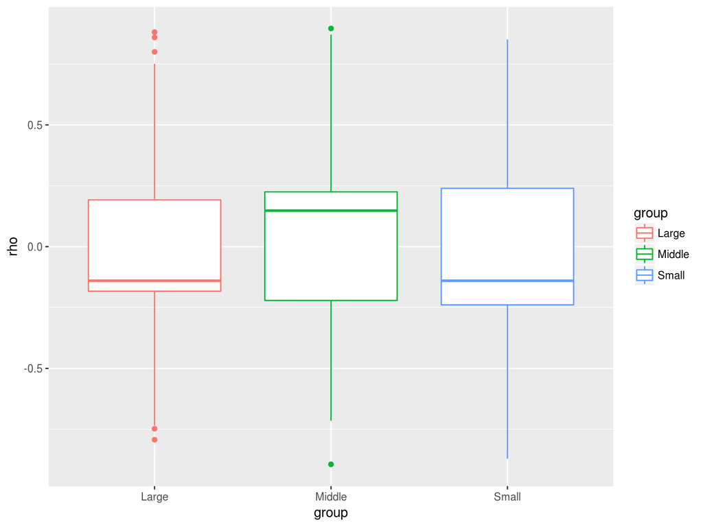

```r
# 保存整理修改后的数据
write_tsv(pgen.3, file.path(dir_out, "pgen_brief.tsv"))
# 图形化比较不同组之间的rho值
ggplot(pgen.3, aes(group, rho, color=group)) + geom_boxplot()
```

```r
# 保存图片
ggsave(file.path(dir_out, "pgen_rho.png"))
```

# 数据分析A：一步到位

除了上述“步步为营”的处理方式外，也可以采用“一步到位”的处理方式：

- 像流水线一样从原始输入直接到最终输出
- 不使用中间变量从而节省计算资源
- 便于提取整理成函数（function）利于重用

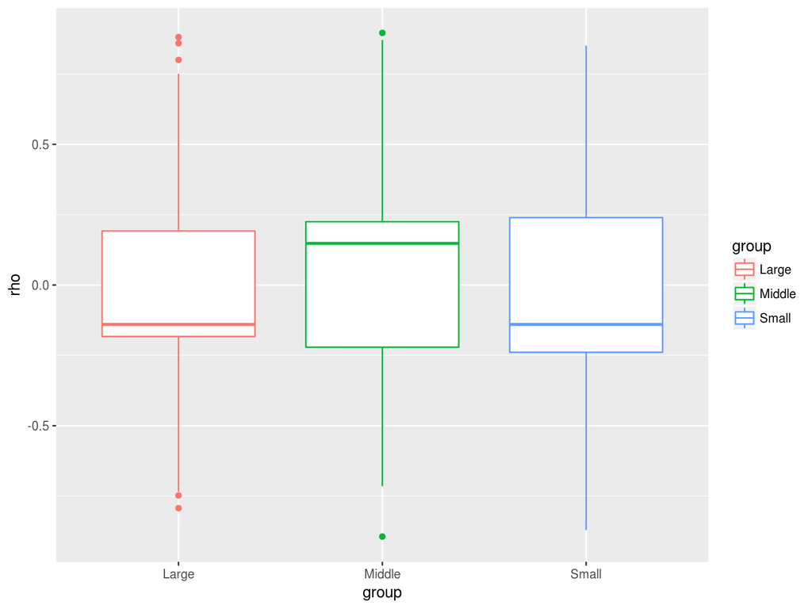

```r
pgen %>% rename(posSNP=`posSNP(hg18)`, posTSS=`posTSS(hg18)`) %>%
  filter(str_detect(SNP, "^rs")) %>%
  select(SNP, gene, chr=chrSNP, posSNP:pvalue) %>% mutate(chr=paste0("chr", chr)) %>%
  mutate(group=ifelse(distanceTSS>=50000, "Large", ifelse(distanceTSS>=20000, "Middle", "Small"))) %>%
  ggplot(aes(group, rho, color=group)) + geom_boxplot()
```

# 数据分析A：Perl版本

Perl程序进行逐行处理，所以一定要提前对数据分析有个整体把握！

```perl
#!/usr/bin/perl

use warnings;
use strict;

my $dir_out = "output_perl";
mkdir $dir_out unless -d $dir_out;
my $fi      = "pgen.tsv";
my $fo      = "$dir_out/pgen_brief.tsv";
open my $I, '<', $fi or die "$0 : failed to open input file '$fi' : $!\n";
open my $O, '>', $fo or die "$0 : failed to open output file '$' : $!\n";
select $O;
print join "\t", "SNP", "gene", "chr", "posSNP", "posTSS", "distanceTSS", "rho", "pvalue", "group";
print "\n";

while (<$I>) {
    if (/^rs\d+/) {
        my @fields = split /\t/;
        my $chr    = "chr" . $fields[3];
        my $group =
          $fields[7] >= 50000
          ? "Large"
          : ( $fields[7] >= 20000 ? "Middle" : "Small" );
        print join "\t", $fields[0], $fields[2], $chr, @fields[ 5 .. 9 ], $group;
        print "\n";
    }
}
close $I or warn "$0 : failed to close input file '$fi' : $!\n";
close $O or warn "$0 : failed to close output file '$' : $!\n";
```

# 数据分析B：输入数据——Genes

- 读入并理解数据

```r
genes <- read_tsv("genes.tsv")
kable(genes[1:5,], format="html") %>%
  kable_styling(bootstrap_options=c("striped", "hover", "condensed", "responsive"), full_width=FALSE, position="left")
```

| PharmGKB Accession Id | NCBI Gene ID | HGNC ID | Ensembl Id | Name | Symbol | Alternate Names | Alternate Symbols | Is VIP | Has Variant Annotation | Cross-references | Has CPIC Dosing Guideline | Chromosome | Chromosomal Start | Chromosomal Stop |
| --- | --- | --- | --- | --- | --- | --- | --- | --- | --- | --- | --- | --- | --- | --- |
| PA24356 | 1 | 5 | ENSG00000121410 | alpha-1-B glycoprotein | A1BG | NA | NA | No | No | NCBI Gene:1“,”OMIM:138670“,”UCSC Genome Browser:NM_130786“,”GO:GO:0000004“,”GO:GO:0005554“,”GO:GO:0005576“,”RefSeq RNA:NM_130786“,”RefSeq Protein:NP_570602“,”RefSeq DNA:NT_011109“,”UniProtKB:P04217“,”… | No | chr19 | 58855172 | 58874865 |
| PA165392995 | 503538 | 37133 | NA | A1BG antisense RNA 1 | A1BG-AS1 | NA | FLJ23569 | No | No | NCBI Gene:503538“,”RefSeq RNA:NR_015380“,”RefSeq DNA:NT_011109“,”GeneCard:A1BG-AS1“,”HGNC:37133 | No | chr19 | 58853336 | 58869549 |
| PA162375098 | 29974 | 24086 | ENSG00000148584 | APOBEC1 complementation factor | A1CF | NA | ACF“,”ACF64“,”ACF65“,”APOBEC1CF“,”ASP | No | No | NCBI Gene:29974“,”GO:GO:0000166“,”GO:GO:0003725“,”GO:GO:0003727“,”GO:GO:0003729“,”GO:GO:0004131“,”GO:GO:0005515“,”GO:GO:0005634“,”GO:GO:0005720“,”GO:GO:0005737“,”GO:GO:0005783“,”GO:GO:0006397“,”GO:GO:… | No | chr10 | 52556169 | 52655435 |
| PA24357 | 2 | 7 | ENSG00000175899 | alpha-2-macroglobulin | A2M | NA | CPAMD5“,”FWP007“,”S863-7 | No | Yes | NCBI Gene:2“,”OMIM:103950“,”OMIM:104300“,”UCSC Genome Browser:NM_000014“,”GO:GO:0004867“,”GO:GO:0005576“,”GO:GO:0006886“,”GO:GO:0008320“,”GO:GO:0017114“,”GO:GO:0019899“,”GO:GO:0019959“,”GO:GO:0019966“… | No | chr12 | 9217304 | 9278558 |
| PA142670460 | 144568 | 23336 | ENSG00000166535 | alpha-2-macroglobulin-like 1 | A2ML1 | CPAMD9 | FLJ25179 | No | No | NCBI Gene:144568“,”OMIM:610627“,”GO:GO:0004866“,”RefSeq RNA:NM_144670“,”RefSeq Protein:NP_653271“,”RefSeq DNA:NT_009714“,”UniProtKB:B3KVV6“,”Ensembl:ENSG00000166535“,”GeneCard:A2ML1“,”ALFRED:LO040147Q… | No | chr12 | 8965150 | 9032381 |

```r
glimpse(genes)
```

```
## Observations: 27,008
## Variables: 15
## $ `PharmGKB Accession Id`     <chr> "PA24356", "PA165392995", "PA16237...
## $ `NCBI Gene ID`              <int> 1, 503538, 29974, 2, 144568, 3, 12...
## $ `HGNC ID`                   <int> 5, 37133, 24086, 7, 23336, 8, 3000...
## $ `Ensembl Id`                <chr> "ENSG00000121410", NA, "ENSG000001...
## $ Name                        <chr> "alpha-1-B glycoprotein", "A1BG an...
## $ Symbol                      <chr> "A1BG", "A1BG-AS1", "A1CF", "A2M",...
## $ `Alternate Names`           <chr> NA, NA, NA, NA, "CPAMD9", NA, "A3G...
## $ `Alternate Symbols`         <chr> NA, "FLJ23569", "ACF\",\"ACF64\",\...
## $ `Is VIP`                    <chr> "No", "No", "No", "No", "No", "No"...
## $ `Has Variant Annotation`    <chr> "No", "No", "No", "Yes", "No", "No...
## $ `Cross-references`          <chr> "NCBI Gene:1\",\"OMIM:138670\",\"U...
## $ `Has CPIC Dosing Guideline` <chr> "No", "No", "No", "No", "No", "No"...
## $ Chromosome                  <chr> "chr19", "chr19", "chr10", "chr12"...
## $ `Chromosomal Start`         <int> 58855172, 58853336, 52556169, 9217...
## $ `Chromosomal Stop`          <int> 58874865, 58869549, 52655435, 9278...
```

```r
summary(genes)
```

```
##  PharmGKB Accession Id  NCBI Gene ID          HGNC ID
##  Length:27008          Min.   :        1   Min.   :    5
##  Class :character      1st Qu.:     8102   1st Qu.: 8652
##  Mode  :character      Median :    55762   Median :17018
##                        Mean   :  6794386   Mean   :17793
##                        3rd Qu.:   252952   3rd Qu.:26708
##                        Max.   :102724631   Max.   :51375
##                        NA's   :166         NA's   :762
##   Ensembl Id            Name              Symbol
##  Length:27008       Length:27008       Length:27008
##  Class :character   Class :character   Class :character
##  Mode  :character   Mode  :character   Mode  :character
##
##
##
##
##  Alternate Names    Alternate Symbols     Is VIP
##  Length:27008       Length:27008       Length:27008
##  Class :character   Class :character   Class :character
##  Mode  :character   Mode  :character   Mode  :character
##
##
##
##
##  Has Variant Annotation Cross-references   Has CPIC Dosing Guideline
##  Length:27008           Length:27008       Length:27008
##  Class :character       Class :character   Class :character
##  Mode  :character       Mode  :character   Mode  :character
##
##
##
##
##   Chromosome        Chromosomal Start   Chromosomal Stop
##  Length:27008       Min.   :       -1   Min.   :       -1
##  Class :character   1st Qu.: 21174526   1st Qu.: 21222713
##  Mode  :character   Median : 50636648   Median : 50677154
##                     Mean   : 65886391   Mean   : 65943756
##                     3rd Qu.:102361759   3rd Qu.:102400866
##                     Max.   :249190395   Max.   :249218453
##
```

# 数据分析：明确任务

1. 丢弃NCBI/HGNC/Ensembl ID为`NA`的记录
2. 仅保留以下变量：PharmGKB, NCBI, Name, Symbol, Chr, Start, End
3. 基于Start和End变量计算长度（Length）
4. 对变量进行重排
5. 绘制Length分布图
6. 比较不同染色体之间的数目差异
   - 数据：按数目从多到少对染色体进行排序
   - 绘图
   - 保存：数据+绘图

# 数据分析B：步步为营

```r
# 指定输出目录
dir_out <- "output_r"
# 修改变量名便于后续使用
genes.0 <- genes %>% rename(PharmGKB=`PharmGKB Accession Id`, NCBI=`NCBI Gene ID`, HGNC=`HGNC ID`, Ensembl=`Ensembl Id`, AltName=`Alternate Names`, AltSym=`Alternate Symbols`, Vip=`Is VIP`, Annotate=`Has Variant Annotation`, Ref=`Cross-references`, Guide=`Has CPIC Dosing Guideline`, Chr=Chromosome, Start=`Chromosomal Start`, End=`Chromosomal Stop`)
#ens_err <- genes.0 %>% filter(!str_detect(Ensembl, "^E\\w+\\d$") | is.na(Ensembl))
# 丢弃NCBI/HGNC/Ensembl ID为`NA`的记录
genes.1 <- genes.0 %>% drop_na(NCBI, HGNC, Ensembl)
# 按需保留变量
genes.2 <- genes.1 %>% select(PharmGKB, NCBI, Name, Symbol, Chr, Start, End)
# 基于Start和End计算长度
genes.3 <- genes.2 %>% mutate(Length=End-Start)
# 重排变量顺序
genes.4 <- genes.3 %>% select(PharmGKB, NCBI, Symbol:Length, Name)
# 展示数据
kable(genes.4[1:5,], format="html") %>%
  kable_styling(bootstrap_options=c("striped", "hover", "condensed", "responsive"), full_width=FALSE, position="left")
```

| PharmGKB | NCBI | Symbol | Chr | Start | End | Length | Name |
| --- | --- | --- | --- | --- | --- | --- | --- |
| PA24356 | 1 | A1BG | chr19 | 58855172 | 58874865 | 19693 | alpha-1-B glycoprotein |
| PA162375098 | 29974 | A1CF | chr10 | 52556169 | 52655435 | 99266 | APOBEC1 complementation factor |
| PA24357 | 2 | A2M | chr12 | 9217304 | 9278558 | 61254 | alpha-2-macroglobulin |
| PA142670460 | 144568 | A2ML1 | chr12 | 8965150 | 9032381 | 67231 | alpha-2-macroglobulin-like 1 |
| PA24359 | 53947 | A4GALT | chr22 | 43085123 | 43127307 | 42184 | alpha 1,4-galactosyltransferase |

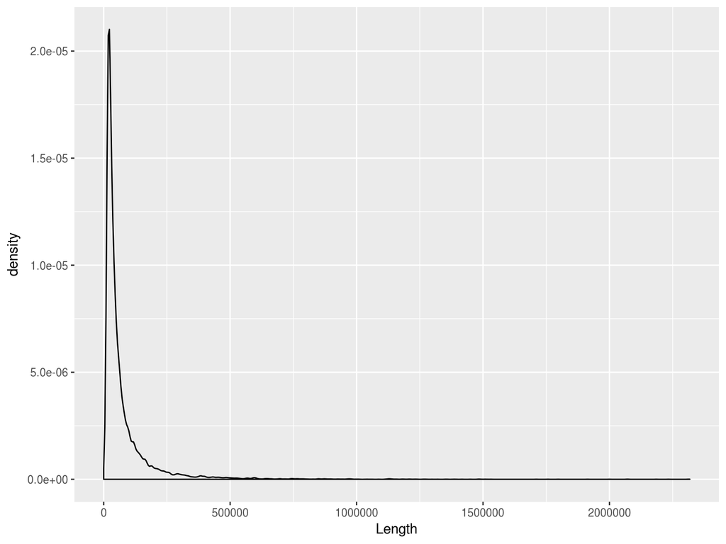

```r
# 保存数据
write_tsv(genes.4, file.path(dir_out, "genes_brief.tsv"))
# 绘图展示长度分布
ggplot(genes.4, aes(Length)) + geom_density()
```

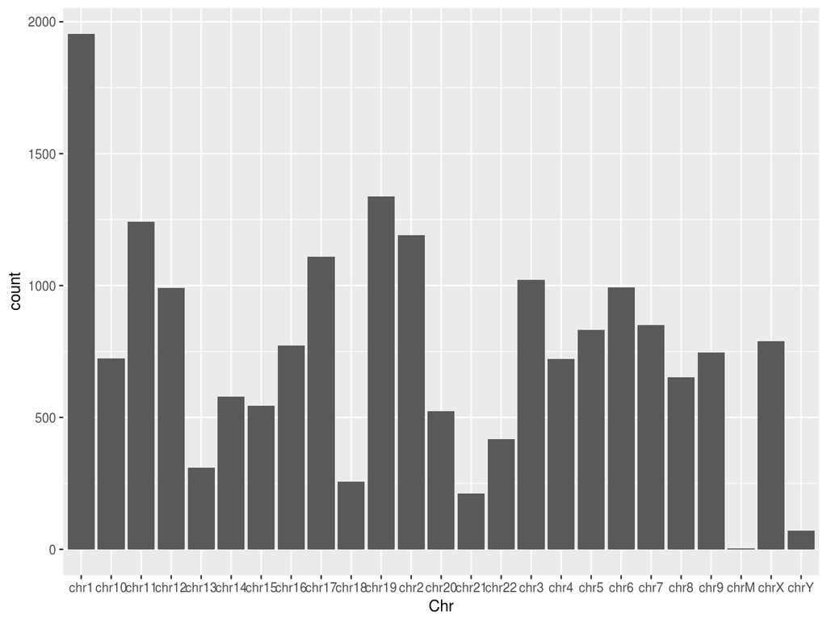

```r
# 保存绘图
ggsave(file.path(dir_out, "length_distribution.png"))
# 绘图展示染色体间的数目差异
ggplot(genes.4, aes(Chr)) + geom_bar()
```

```r
# 保存绘图
ggsave(file.path(dir_out, "chr_number_barplot.png"))
# 按照数目从多到少对染色体进行排序
chr_count <- genes.4 %>% group_by(Chr) %>% summarise(Count=n()) %>% arrange(desc(Count))
# 展示数据
kable(chr_count[1:5,], format="html") %>%
  kable_styling(bootstrap_options=c("striped", "hover", "condensed", "responsive"), full_width=FALSE, position="left")
```

| Chr | Count |
| --- | --- |
| chr1 | 1955 |
| chr19 | 1337 |
| chr11 | 1242 |
| chr2 | 1191 |
| chr17 | 1109 |

```r
# 保存数据
write_tsv(chr_count, file.path(dir_out, "genes_chr_number.tsv"))
```

# 数据分析B：一步到位

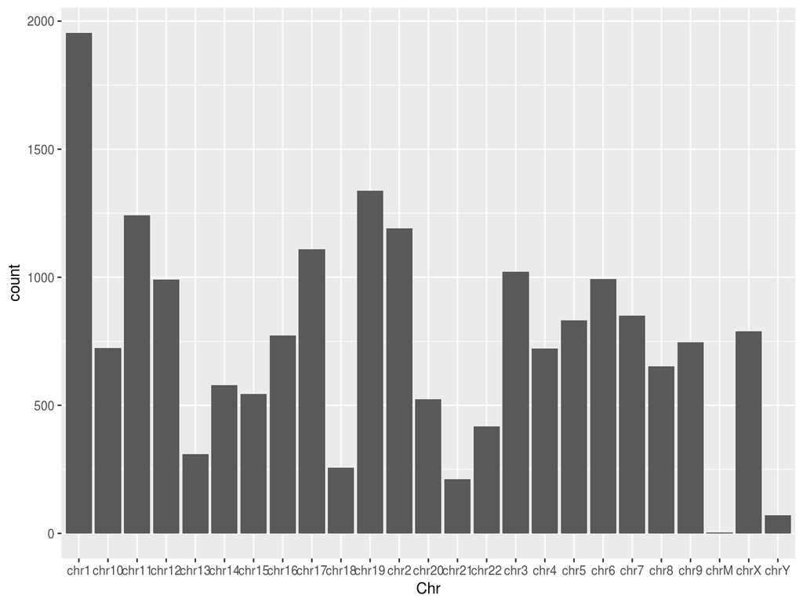

```r
genes %>% rename(PharmGKB=`PharmGKB Accession Id`, NCBI=`NCBI Gene ID`, HGNC=`HGNC ID`, Ensembl=`Ensembl Id`, AltName=`Alternate Names`, AltSym=`Alternate Symbols`, Vip=`Is VIP`, Annotate=`Has Variant Annotation`, Ref=`Cross-references`, Guide=`Has CPIC Dosing Guideline`, Chr=Chromosome, Start=`Chromosomal Start`, End=`Chromosomal Stop`) %>%
  drop_na(NCBI, HGNC, Ensembl) %>%
  select(PharmGKB, NCBI, Name, Symbol, Chr, Start, End) %>%
  mutate(Length=End-Start) %>%
  select(PharmGKB, NCBI, Symbol:Length, Name) %>%
  ggplot(aes(Chr)) + geom_bar()
```

# 数据分析B：Perl版本

```perl
#!/usr/bin/perl

use warnings;
use strict;

my $dir_out    = "output_perl";
mkdir $dir_out unless -d $dir_out;
my $file_genes = "genes.tsv";
my $file_out   = "$dir_out/genes_brief.tsv";
open my $I, '<', $file_genes or die "$0 : failed to open input file '$file_genes' : $!\n";
open my $O, '>', $file_out or die "$0 : failed to open output file '$file_out' : $!\n";
select $O;
print join "\t", "PharmGKB", "NCBI", "Symbol", "Chr", "Start", "End", "Length", "Name";
print "\n";
my %number;

while (<$I>) {
    chomp;
    unless (/^Pham/) {
        my @fields = split /\t/;
        if ( $fields[1] =~ /\d/ && $fields[2] =~ /\d/ && $fields[3] =~ /\w/ ) {
            my $length = $fields[-1] - $fields[-2];
            $number{ $fields[-3] }++;
            print join "\t", @fields[ 0, 1, 5, -3, -2, -1 ], $length, $fields[4];
            print "\n";
        }
    }
}
close $I or warn "$0 : failed to close input file '$file_genes' : $!\n";
close $O or warn "$0 : failed to close output file '$file_out' : $!\n";

my $file_number = "$dir_out/genes_chr_num.tsv";
open my $ON, '>', $file_number or die "$0 : failed to open output file '$file_number' : $!\n";
select $ON;
print "Chr\tCount\n";
foreach my $key ( sort { $number{$b} <=> $number{$a} } keys %number ) {
    print "$key\t$number{$key}\n";
}
close $ON or warn "$0 : failed to close output file '$file_number' : $!\n";
```

# 数据分析C：输入数据——Phewas

- 读入并理解数据

```r
phewas <- read_csv("phewas.csv", na=c("", "NA", "NULL"))
kable(phewas[1:5,], format="html") %>%
  kable_styling(bootstrap_options=c("striped", "hover", "condensed", "responsive"), full_width=FALSE, position="left")
```

| chromosome | snp | phewas phenotype | cases | p-value | odds-ratio | gene_name | phewas code | gwas-associations |
| --- | --- | --- | --- | --- | --- | --- | --- | --- |
| 19 45395619 | rs2075650 | Alzheimer’s disease | 737 | 0 | 2.410 | TOMM40 | 290.11 | Alzheimer’s disease, Alzheimer’s disease biomarkers, Amyloid Beta Peptide 1-42, LDL Cholesterol, C-reactive protein, Total Cholesterol, Grey matter density |
| 19 45395619 | rs2075650 | Dementias | 1170 | 0 | 2.114 | TOMM40 | 290.1 | Alzheimer’s disease, Alzheimer’s disease biomarkers, Amyloid Beta Peptide 1-42, LDL Cholesterol, C-reactive protein, Total Cholesterol, Grey matter density |
| 6 396321 | rs12203592 | Actinic keratosis | 2505 | 0 | 1.691 | IRF4 | 702.1 | Eye color, Hair color, Freckling, Progressive supranuclear palsy |
| 6 26093141 | rs1800562 | Iron metabolism disorder | 40 | 0 | 12.270 | HFE | 275.1 | Mean corpuscular hemoglobin, Glycated hemoglobin, LDL Cholesterol, Transferrin saturation, Serum iron, Hematocrit, Total Transferrin, Mean corpuscular volume, Total Cholesterol, Serum transferrin, Fer… |
| 19 45395619 | rs2075650 | Delirium dementia and amnestic disorders | 1566 | 0 | 1.841 | TOMM40 | 290 | Alzheimer’s disease, Alzheimer’s disease biomarkers, Amyloid Beta Peptide 1-42, LDL Cholesterol, C-reactive protein, Total Cholesterol, Grey matter density |

```r
glimpse(phewas)
```

```
## Observations: 215,107
## Variables: 9
## $ chromosome          <chr> "19 45395619", "19 45395619", "6 396321", ...
## $ snp                 <chr> "rs2075650", "rs2075650", "rs12203592", "r...
## $ `phewas phenotype`  <chr> "Alzheimer's disease", "Dementias", "Actin...
## $ cases               <int> 737, 1170, 2505, 40, 1566, 749, 1931, 40, ...
## $ `p-value`           <dbl> 5.237e-28, 2.409e-26, 4.141e-26, 3.409e-25...
## $ `odds-ratio`        <dbl> 2.4100, 2.1140, 1.6910, 12.2700, 1.8410, 0...
## $ gene_name           <chr> "TOMM40", "TOMM40", "IRF4", "HFE", "TOMM40...
## $ `phewas code`       <chr> "290.11", "290.1", "702.1", "275.1", "290"...
## $ `gwas-associations` <chr> "Alzheimer's disease, Alzheimer's disease ...
```

```r
summary(phewas)
```

```
##   chromosome            snp            phewas phenotype       cases
##  Length:215107      Length:215107      Length:215107      Min.   :  25
##  Class :character   Class :character   Class :character   1st Qu.:  80
##  Mode  :character   Mode  :character   Mode  :character   Median : 228
##                                                           Mean   : 582
##                                                           3rd Qu.: 615
##                                                           Max.   :8185
##     p-value          odds-ratio        gene_name
##  Min.   :0.00000   Min.   : 0.07705   Length:215107
##  1st Qu.:0.01241   1st Qu.: 0.77980   Class :character
##  Median :0.02497   Median : 1.12400   Mode  :character
##  Mean   :0.02494   Mean   : 1.11070
##  3rd Qu.:0.03747   3rd Qu.: 1.36400
##  Max.   :0.05000   Max.   :33.88000
##  phewas code        gwas-associations
##  Length:215107      Length:215107
##  Class :character   Class :character
##  Mode  :character   Mode  :character
##
##
##
```

# 数据分析C：明确任务

1. 丢弃位置信息缺失或者基因名（gene）为`NULL`的记录
2. 把染色体和位置从一个变量分割为两个变量，同时把染色体整理成“chrN”的格式
3. 仅保留case number超过100、且odds ratio大于1的记录
4. 按需选择变量，并进行重排
5. 找到含有最多SNP、排名前15的基因
   1. 计算每个基因上的SNP数目
   2. 根据数目选在排名前15的基因
   3. 补充这些基因的SNP具体信息